# DM02

**演習では，他人のデバイスに触らない．自分のデバイスを，他人に触らせない．**

**新しいノートブックは作らない．**前回（宿題で）作業したノートブックは，Google Driveの「マイドライブ/Colab Notebooks」に保存されているはず．それを開いて再開する．

結果を提示しているのは，計算が正しいことを確認してもらうためである．結果の形式を完全に同じにする必要はない．

## 1 ベクトル（教科書3.3.2項）

**課題** $\boldsymbol x=(x_1,\dots,x_n)=(57, 39, 59, 59, 48, 38)$ とする．これを次のデータ構造で表し，それぞれの要素数を求めよ．

- アレイ`a`
- シリーズ`s`

**課題** $\boldsymbol x$ の各成分に $10$ を足した結果を求めよ．

**課題** $10\boldsymbol x$ を求めよ．

**課題** $\boldsymbol y=(y_1,\dots,y_n)=(1, 2, 3, 4, 5, 6)$ とする．$\boldsymbol x+\boldsymbol y$ を求めよ．

**課題** $\displaystyle\sum_{i=1}^nx_i$ を求めよ．

**課題** $\boldsymbol x\cdot\boldsymbol y=\displaystyle\sum_{i=1}^nx_iy_i$ を求めよ．

**課題** $(x_1^2,\dots,x_n^2)$ を求めよ．

**課題** $\lvert\boldsymbol x\rvert=\sqrt{\boldsymbol x\cdot\boldsymbol x}=\sqrt{\sum_{i=1}^nx_i^2}$ を求めよ．

## 2 記述統計（教科書4.1節）

**課題** $\bar{x}=\displaystyle\frac{1}{n}\sum_{i=1}^nx_i$ を求めよ．

**課題** $V=\displaystyle\frac{1}{n-1}\sum_{i=1}^n(x_i-\bar x)^2$ を求めよ．

**課題** $\sigma=\displaystyle\sqrt{\frac{1}{n-1}\sum_{i=1}^n(x_i-\bar x)^2}$ を求めよ．

**課題** $z_i=\dfrac{x_i-\bar x}{\sigma}$ を求めよ．

**課題** $\bar z=\displaystyle\frac{1}{n}\sum_{i=1}^nz_i$ を求めよ．

**課題** $\displaystyle\sqrt{\frac{1}{n-1}\sum_{i=1}^n(z_i-\bar z)^2}$ を求めよ．

**課題** $x_1, \dots, x_n$ の偏差値 $t_1, \dots, t_n$ を求めよ．

**課題** $\bar t=\displaystyle\frac{1}{n}\sum_{i=1}^nt_i$ を求めよ．

**課題** $\displaystyle\sqrt{\frac{1}{n-1}\sum_{i=1}^n(t_i-\bar t)^2}$ を求めよ．

**課題** `df.test1`の平均を求めよ．

## 3 1次元データの（非）類似度（教科書3.5節）

`df.test1`を $\boldsymbol x=\{x_1,\dots x_n\}$，`df.test2`を $\boldsymbol y=\{y_1,\dots,y_n\}$ とする．

**課題** $\lvert\boldsymbol x-\boldsymbol y\rvert=\sqrt{\sum_{i=1}^n(x_i-y_i)^2}$ を求めよ．

**課題** $r=\dfrac{\sum_{i=1}^n(x_i-\bar x)(y_i-\bar y)}{\sqrt{\sum_{i=1}^n(x_i-\bar x)^2}\sqrt{\sum_{i=1}^n(y_i-\bar y)^2}}$を求めよ．

**課題** $\cos\theta=\dfrac{\boldsymbol x\cdot\boldsymbol y}{\lvert\boldsymbol x\rvert\lvert\boldsymbol y\rvert}=\dfrac{\sum_{i=1}^nx_iy_i}{\sqrt{\sum_{i=1}^nx_i^2}\sqrt{ \sum_{i=1}^ny_i^2}}$ を求めよ．

**課題** `df`のAとBのユークリッド距離を求めよ（classは無視する）．

**課題** `df[['test1', 'test2']]`の各個体間のユークリッド距離を求めよ（classは無視する）．

## 4 データの可視化（教科書4.2節）

**課題** `df['test2']`を，次のように可視化せよ．

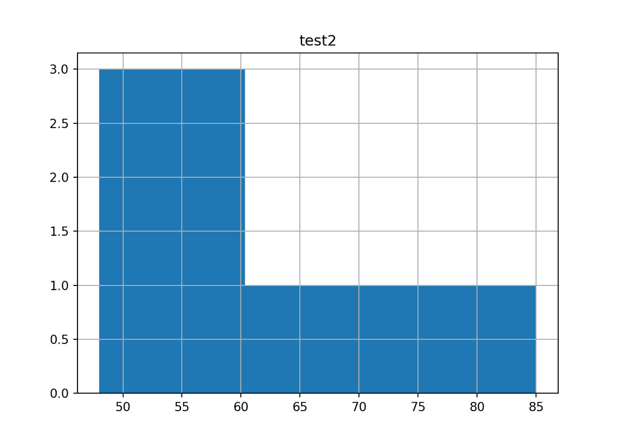

**課題** test1とtest2の関係を，次のように可視化せよ．

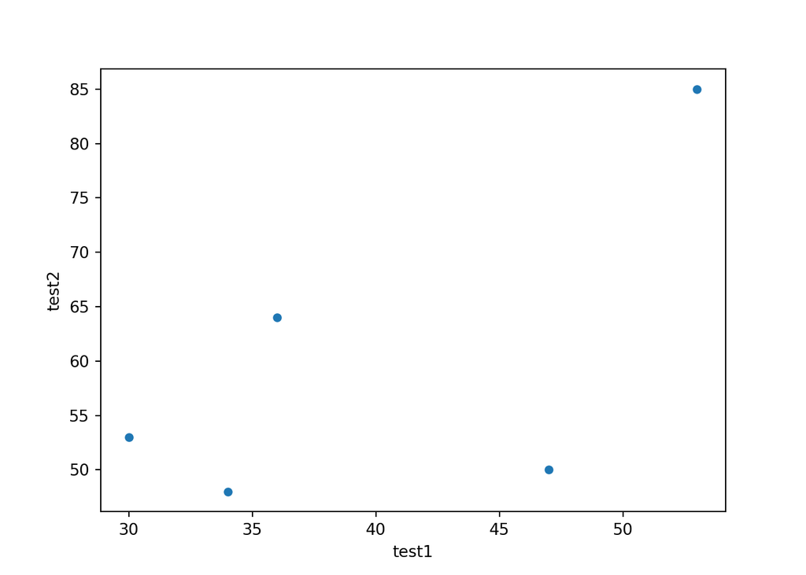

**課題** 2変数の分布を，次のように可視化せよ．

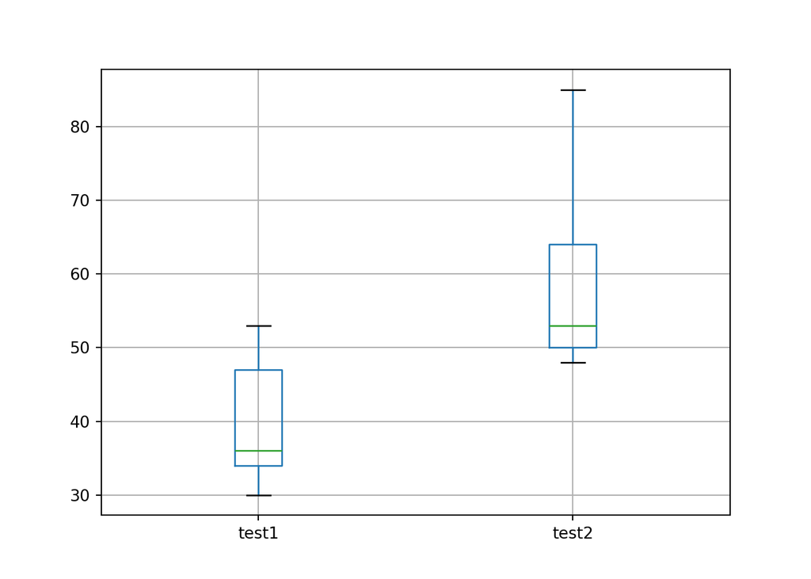

**課題** $y=x^2$ $(-1\le x\le 2)$ を，次のように可視化せよ．

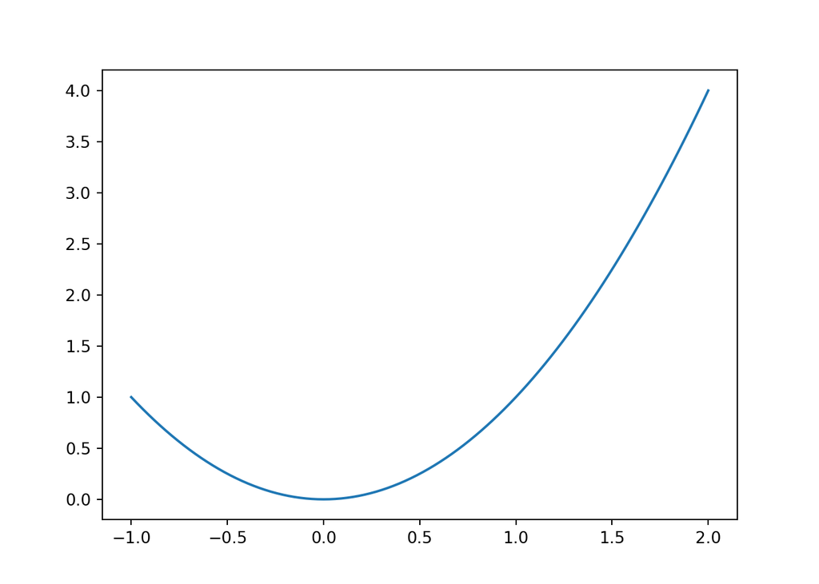

**課題** $z=x^2+y^2$ $(-1\le x\le 1, -1\le y\le 1)$ を，次のように可視化せよ．

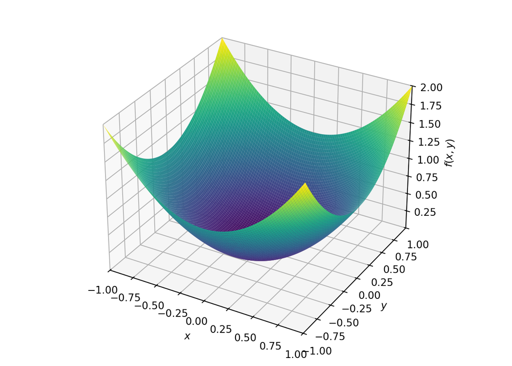

**課題** $z=x^2+y^2$ $(-1\le x\le 1, -1\le y\le 1)$ を，次のように可視化せよ．

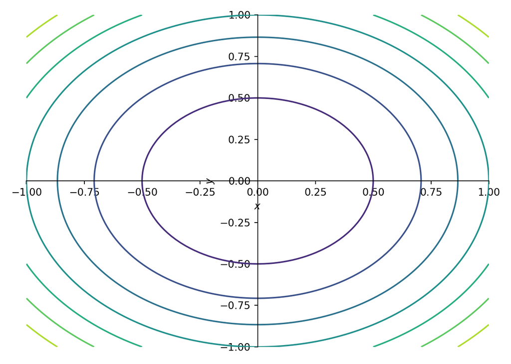

**課題** （時間に余裕がある場合）生成AIで全てをやり直せ．